# Stroop Effect Perceptual Phenomenon

Mahlon Barrault

December 4, 2016

## Stroop Task Study Parameters

In a Stroop task the subject is asked to read two lists of colored words one after the other. The first list has names of colors printed in ink that matches the color name. This is the congruent list. In the second list the names of the colors do not match. This is the incongruent list. In both cases the subject is asked to say the color of the ink the word is written in. The time it takes to read each list is recorded. This study follows the repeated measures design pattern.

The independent variable is the list of words and the dependent variable is the time to read the list. The null hypothesis in this case would be that the mean time to read the congruent list minus the mean time to read the incongruent list would be 0 and an alternative hypothesis would be that the means are not equal. Symbolically my hypotheses are:

$$H_0 : \mu_C = \mu_I$$
$$H_a : \mu_C \neq \mu_I$$

Where $\mu_C$ is the population mean of the congruent reading times and $\mu_I$ is the population mean of the incongruent reading times.

To test these hypotheses, it would be appropriate to use a two-tailed t-test. Since we do not know the population parameters a t-test is the best fit. A two-tailed test is relevant in this case because we are only interested in if a subject’s performance differs between the lists. We are not making any assumptions about the directionality of potential differences. For the t-test $\alpha = 0.05$ will be used.

Having participated in a Stroop task myself, I am inclined to think that the statistics will show that reading the incongruent list is a much more cognitively demanding task.

## Analysis

```r
# You might need to reverse the slashes depending what OS you are on
stroop <- read.csv("../data/stroopdata.csv")

# Count the rows in the data set
n <- nrow(stroop)
df <- n - 1

# Calculate mean of reach column
x_C <-  mean(stroop$Congruent)
x_I <- mean(stroop$Incongruent)

# Calculate standard diviation of each column
s_C <- sd(stroop$Congruent)
s_I <- sd(stroop$Incongruent)
```

The following is a summary of the statistics for the Stroop task observations in this sample:

$$\bar{x}_C = 14.051125$$
$$s_C = 3.559358$$

$$\bar{x}_I = 22.0159167$$
$$s_I = 4.7970571$$

Where $\bar{x}_C$ is the mean of the congruent list reading times, $s_C$ is the standard deviation of the congruent list reading times, $\bar{x}_I$ is the mean of the incongruent list reading times, and $s_I$ is the standard diviation of the incongruent list reading times.

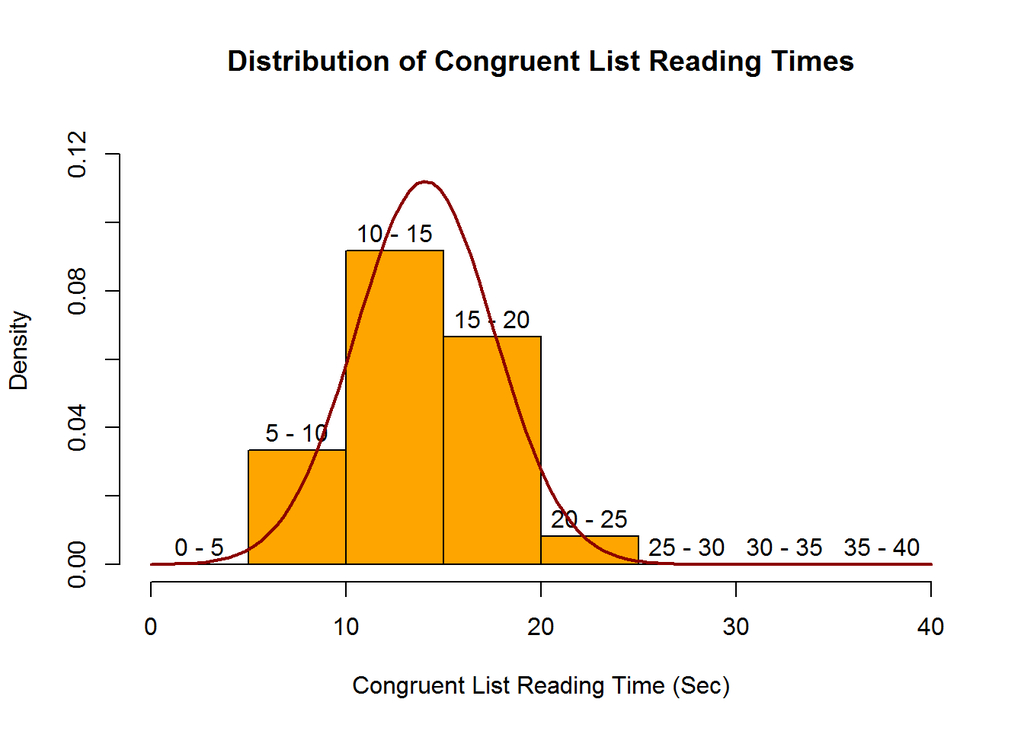

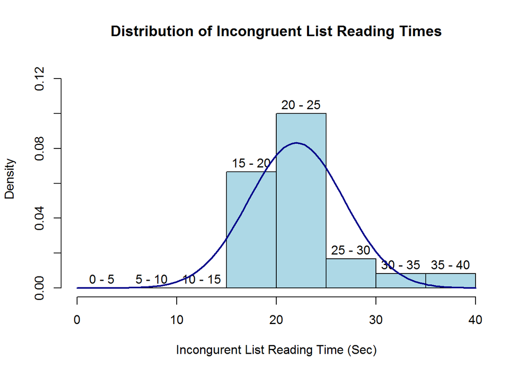

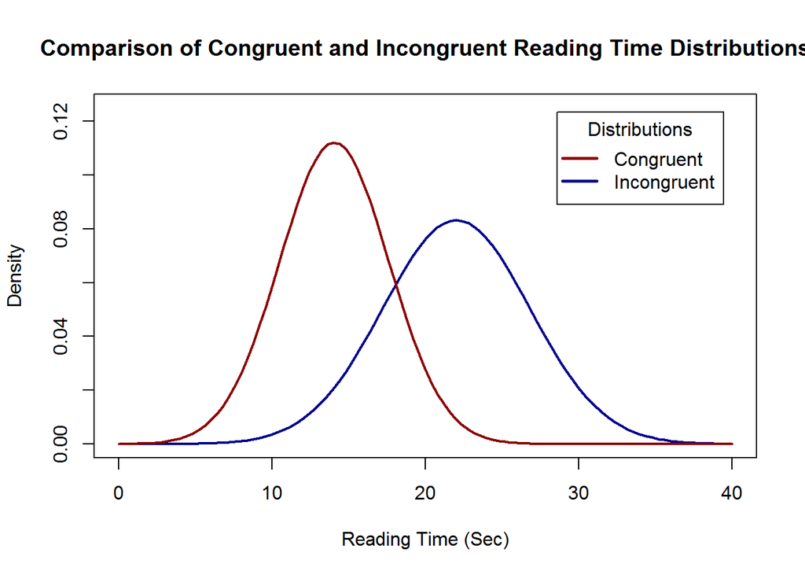

A normal distribution curve was plotted on top of the histograms for visual confirmation that these data appear to be normally distributed.

Despite the clear numerical and visual differences, that alone is not enough to accept or reject $H_0$. Next we will conduct a t-test to determine the statistical significance of what we have observed so far.

### Hypothesis Test

```r
# Setting 'paired = TRUE' the t.test function uses the difference between the means of the two input lists
t = t.test(x = stroop$Congruent, y = stroop$Incongruent, var.equal = FALSE, paired = TRUE)
```

The results of the t-test were:
$$t_\textrm{crit}(23) = \pm 2.069, \alpha = 0.05, two-tailed$$
$$t(23) = -8.0207069, p = 4.1030006\times 10^{-8}, two-tailed$$

Confidence Interval on difference between the means:
$$95\% CI = (-5.9105554, -10.0190279)$$

From these results we can safely reject $H_0$. With the large absolute t-score and extremely low p-value we can say that the difference between these two distributions is not a result of random fluctuations. In terms of the experiment, we can now say that the differences between the reading times is not a result of natural variability, but a result of a change in our independant variable - the list of words.

Since statistical significance is only part of the picture, next we will examine some effect size measures.

### Effect Size

```r
# Calculate r^2
r.squared <- t$statistic^2 / (t$statistic^2 + df)

# Calculate standard diviation of of the differences
s <- sd(stroop$Congruent - stroop$Incongruent)

# t-test calculated the mean difference already
M_D <- t$estimate

# Calculate d
cohens.d <- M_D / s
```

$$r^2 = 0.7366364$$
$$d = -1.6372199$$

The $r^2$ statistic is telling us that about 74% of the variance in reading times between the congruent list and the incongruent list can be explained by the difference between the two lists. $d$ is telling us that the two distributions are offset and by about 1.6 standard deviations.

## Conclusion

During the analysis of the Stroop task sample there were several important findings. By comparing the means and standard deviations between the reading times of the congruent list and the incongruent list there was indication that an effect might be present. The data were plotted and this confirmed visually what was noticed by comparing the descriptive statistics of the sample. To confirm the differences were statistically significant a two-tailed t-test was used. The t-test indicated that there was a strong effect as a result of the change in the independant variable. $r^2$ and $d$ effect size measures were calculated to get a sense for the magnitude of the effect.

Based on these findings it is clear that reading a list of color names printed in ink that is a different color from the printed name is a challenging cognitive task.

As I was conducting this analysis I was curious if there was a variation of the Stroop task using numbers rather than colored words. I thought the test could be conducted in a similar way. The subject would be asked to speak aloud how many digits were in each set. The congruent list could be composed of groups of the same number repeated that number of times.

$$4444, 1, 333, 22$$
The incongruent list would be groups of the same number repeated a different number of times.

$$2222, 3, 444, 11$$

I wondered if there was any validity to this idea so I did some research and found that a Stroop test involving numbers has been conducted but it was more so to study the effects of the size of the printed numbers in relation to each other. I was able to find a “Number Stroop” test online similar to the one I participated in for this project at https://faculty.washington.edu/chudler/java/readyn.html. This test used lists of the word forms of the numbers in incongruent counts. I was still curious if any study has been conducted to see if similar results to the Stroop effect show up when the test uses digits rather than letters.

After some additional digging I found an abstract for a paper entitled “Numerical stroop effect.” at https://www.ncbi.nlm.nih.gov/pubmed/15058867. This study seems to be very similar to the idea I had! It’s good to know I was on the right track. I was hoping to read the paper to find out how they conducted their statistical analysis, but I was not able to obtain a copy. Google Scholar had some citations listed with additional links to the paper on the publisher’s site but I could not find one that worked.